# Preprocess Data

## Marketing Analytics Process

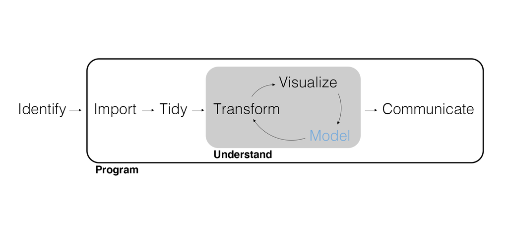

## Inferential Modeling Workflow

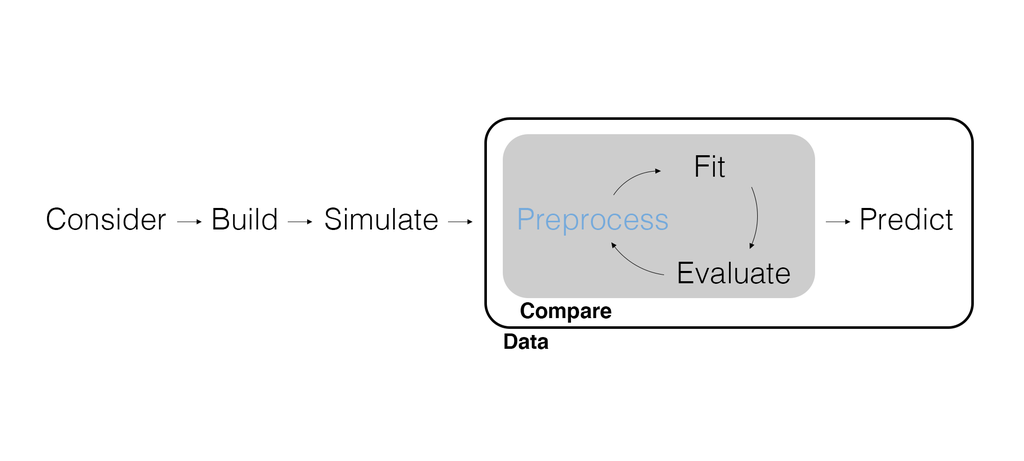

[figure not shown]

## Preprocess Data

So far we have been trying to slowly build intuition about inferential models. Now we want to talk about the data itself. In particular, we often need to **preprocess the data** so it is appropriate for the model to use. This may involve creating new variables as well. This is also known as **feature engineering**. Again, think of *preprocessing* as *data wrangling for models*.

We’ve technically already done some preprocessing: data splitting.

```r
# Load packages.
library(tidyverse)
library(tidymodels)

# Import soup data.
soup_data <- read_csv("soup_data.csv")

# Split data.
soup_split <- initial_time_split(soup_data, prop = 0.90)
```

Preprocessing data is made easier using the recipes package where common preprocessing tasks have been broken down into steps, beginning with a `recipe()` where we identify the model outcome and explanatory variables (a.k.a., predictors) using *formula* notation.

```r
soup_recipe <- training(soup_split) |>
  recipe(Sales ~ Any_Disp_Spend + Any_Price_Decr_Spend + Sub_Category)
```

```r
soup_recipe
```

```
## ── Recipe ──────────────────────────────────────────────────────────────────────
```

```
## ── Inputs
```

```
## Number of variables by role
```

```
## outcome:   1
## predictor: 3
```

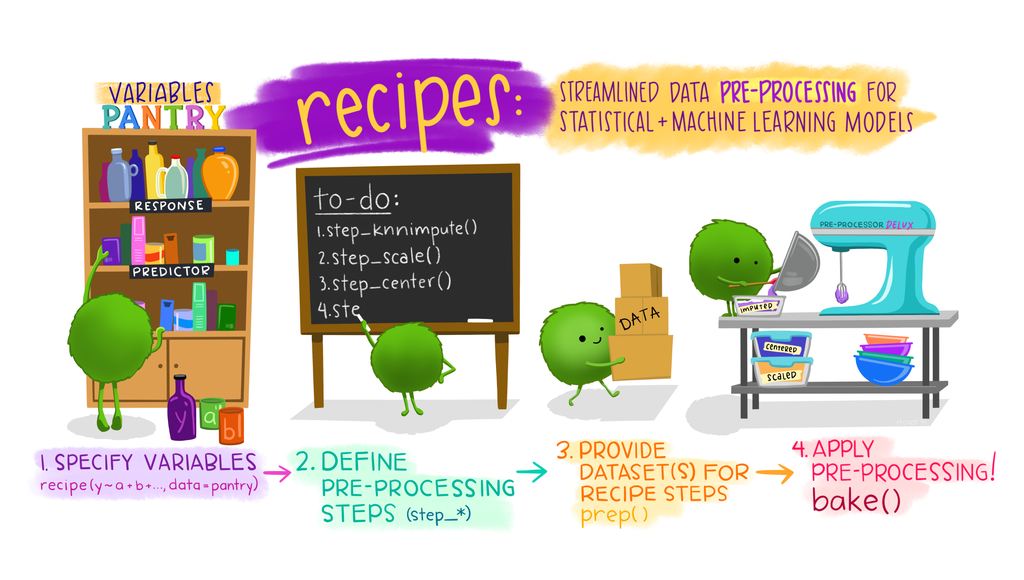

## Here’s How We Think About Recipes…

- The **Data** is our *pantry* - where we find all of the ingredients
- We are making a dish for our guest of honor - the **Model**
- The model expects an outcome variable and explanatory variables prepared in specific ways
- We define a *Recipe* that outlines how our ingredients (outcome and explanatory variables) must be prepared for our model

## What Will We Do Today?

- Discuss some common pre-processing (recipe) steps
- Practice creating a recipe
- See the impact that pre-processing can have on model results

## Right-Skewed Continuous Data

A common problem with data is having **right-skewed continuous data**, something to identify when we’re doing *exploratory data analysis*.

Why is right-skewed continuous data common?

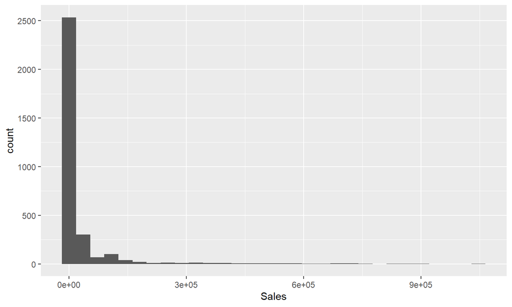

```r
# Visualize Sales.
soup_data |>
  ggplot(aes(x = Sales)) +
  geom_histogram()
```

It’s not just `Sales`.

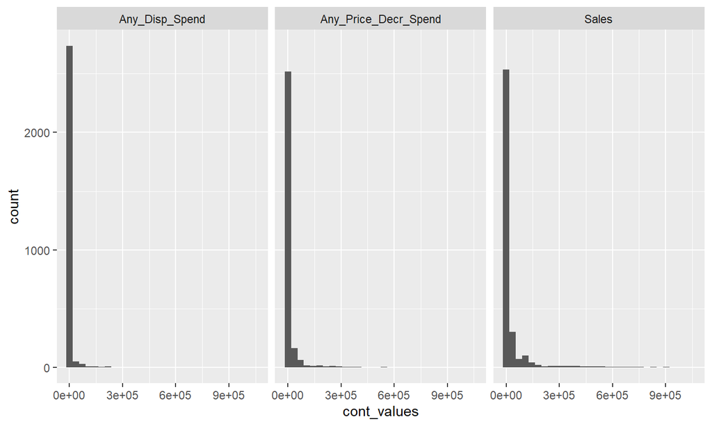

```r
# Visualize all continuous variables.
soup_data |>
  pivot_longer(
    c(Sales, Any_Disp_Spend, Any_Price_Decr_Spend),
    names_to = "var_names",
    values_to = "cont_values"
  ) |>
  ggplot(aes(x = cont_values)) +
  geom_histogram() +
  facet_wrap(~ var_names)
```

## Pause! Why did the plot report that values were removed?

## Let’s Check for Missing Values

```r
soup_data |>
  filter(is.na(Sales) | is.na(Any_Disp_Spend) | is.na(Any_Price_Decr_Spend)) |>
  select(Sales, Any_Disp_Spend, Any_Price_Decr_Spend)
```

```
## # A tibble: 352 × 3
##    Sales Any_Disp_Spend Any_Price_Decr_Spend
##    <dbl>          <dbl>                <dbl>
##  1    33             NA                   NA
##  2  6413             NA                   NA
##  3    30             NA                   NA
##  4  1182             NA                   NA
##  5   415             NA                   NA
##  6   107             NA                   NA
##  7   163             NA                   NA
##  8   669             NA                   NA
##  9   132             NA                   NA
## 10    51             NA                   NA
## # ℹ 342 more rows
```

## Plot without Missing Values

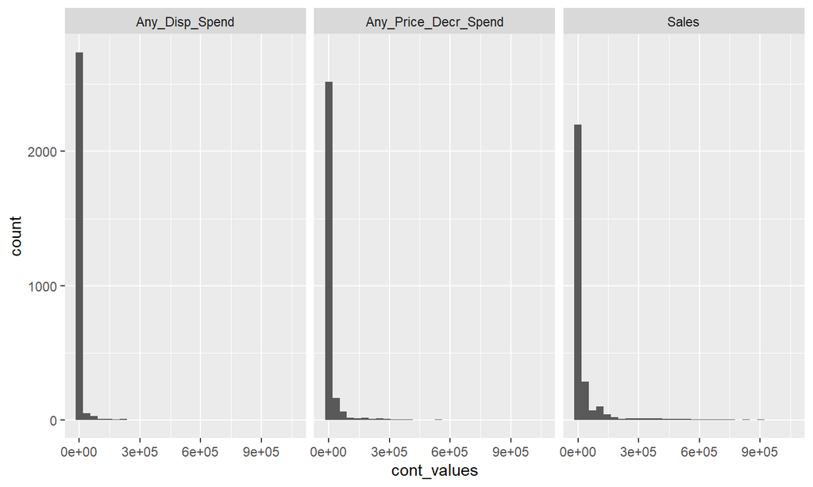

The linear model assumes *normally distributed errors*. This means our Y variable should be approximately normal (or at least as close as we can get it)! We can preprocess right-skewed continuous data by using a `log()` (i.e., logarithmic) transform.

- Why a `log()` transform? What is a logarithm?
- What is the *inverse* of a logarithm?

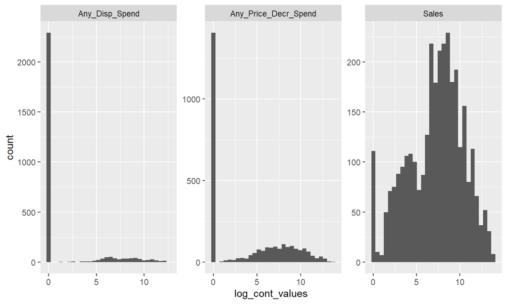

```r
# Use the log() transform.
soup_data |>
  pivot_longer(
    c(Sales, Any_Disp_Spend, Any_Price_Decr_Spend),
    names_to = "var_names",
    values_to = "cont_values"
  ) |>
  mutate(log_cont_values = log(cont_values + 1)) |>
  ggplot(aes(x = log_cont_values)) +
  geom_histogram() +
  facet_wrap(~ var_names, scales = "free")
```

We add this step to our recipe using `step_log()`. We can reference all continuous variables in the model with `all_numeric()`. The argument `offset = 1` says to add 1 before using `log()` so we can avoid `log(0)`.

```r
soup_recipe <- training(soup_split) |>
  recipe(Sales ~ Any_Disp_Spend + Any_Price_Decr_Spend + Sub_Category) |>
  step_log(all_numeric(), offset = 1)

soup_recipe
```

```
## ── Recipe ──────────────────────────────────────────────────────────────────────
```

```
## ── Inputs
```

```
## Number of variables by role
```

```
## outcome:   1
## predictor: 3
```

```
## ── Operations
```

```
## • Log transformation on: all_numeric()
```

## Discrete Data

In additional to right-skewed continuous variables, we also need to pre-process discrete variables. How many binary variables will we have when we dummy code this discrete variable?

```r
soup_data |>
  count(Sub_Category)
```

```
## # A tibble: 5 × 2
##   Sub_Category       n
##   <chr>          <int>
## 1 CONDENSED SOUP   410
## 2 DRY SOUP        1194
## 3 RAMEN            217
## 4 RTS SOUP        1310
## 5 SOUP IN OUT       61
```

We add this step to our recipe using `step_dummy()`. We could reference all discrete variables in the model with `all_nominal()`.

```r
soup_recipe <- training(soup_split) |>
  recipe(Sales ~ Any_Disp_Spend + Any_Price_Decr_Spend + Sub_Category) |>
  step_log(all_numeric(), offset = 1) |>
  step_dummy(Sub_Category)

soup_recipe
```

```
## ── Recipe ──────────────────────────────────────────────────────────────────────
```

```
## ── Inputs
```

```
## Number of variables by role
```

```
## outcome:   1
## predictor: 3
```

```
## ── Operations
```

```
## • Log transformation on: all_numeric()
```

```
## • Dummy variables from: Sub_Category
```

## Prepare a Recipe

We can build the recipe all at once. Once we’re ready, we can `prep()` the recipe using the training data. The resulting object is a complete recipe that we can apply to whatever data we’d like.

```r
soup_recipe <- training(soup_split) |>
  recipe(Sales ~ Any_Disp_Spend + Any_Price_Decr_Spend + Sub_Category) |>
  step_log(all_numeric(), offset = 1) |>
  step_dummy(Sub_Category) |>
  prep()
```

## Apply a Recipe

Following the recipe analogy, we apply a prepared recipe to data using `bake()`.

```r
# Apply the recipe to the training data.
baked_soup_training <- soup_recipe |>
  bake(training(soup_split))
```

```r
baked_soup_training
```

```
## # A tibble: 2,872 × 7
##    Any_Disp_Spend Any_Price_Decr_Spend Sales Sub_Category_DRY.SOUP
##             <dbl>                <dbl> <dbl>                 <dbl>
##  1           0                    0     6.73                     0
##  2           9.71                10.8  13.1                      0
##  3           0                    0     4.52                     0
##  4           0                    7.58 11.8                      0
##  5           0                    0     3.93                     1
##  6           0                    0    10.2                      1
##  7           0                    0     4.91                     1
##  8           0                    0     0                        1
##  9           2.30                 0     8.74                     1
## 10           0                    0     1.61                     1
## # ℹ 2,862 more rows
## # ℹ 3 more variables: Sub_Category_RAMEN <dbl>, Sub_Category_RTS.SOUP <dbl>,
## #   Sub_Category_SOUP.IN.OUT <dbl>
```

## Fit with Preprocessed Training Data

Let’s compare models with and without the preprocessed data.

```r
# Fit a model without preprocessed data.
fit_raw <- linear_reg() |>
  set_engine("lm") |>
  fit(
    Sales ~ Any_Disp_Spend + Any_Price_Decr_Spend + Sub_Category,
    data = training(soup_split)
  )

# Fit a model with preprocessed data.
fit_baked <- linear_reg() |>
  set_engine("lm") |>
  fit(
    Sales ~ .,
    data = baked_soup_training
  )
```

## Evaluate Parameter Estimates

If we want to use it, there is a horizontal version of the error bars plot.

```r
# Compare parameter estimates.
tidy(fit_baked, conf.int = TRUE) |>
  ggplot(aes(y = term)) +
  geom_point(aes(x = estimate)) +
  geom_errorbar(aes(xmin = conf.low, xmax = conf.high), orientation = 'y') +
  geom_vline(xintercept = 0, color = "red")
```

## Error Bar plot for ‘Raw’ Data

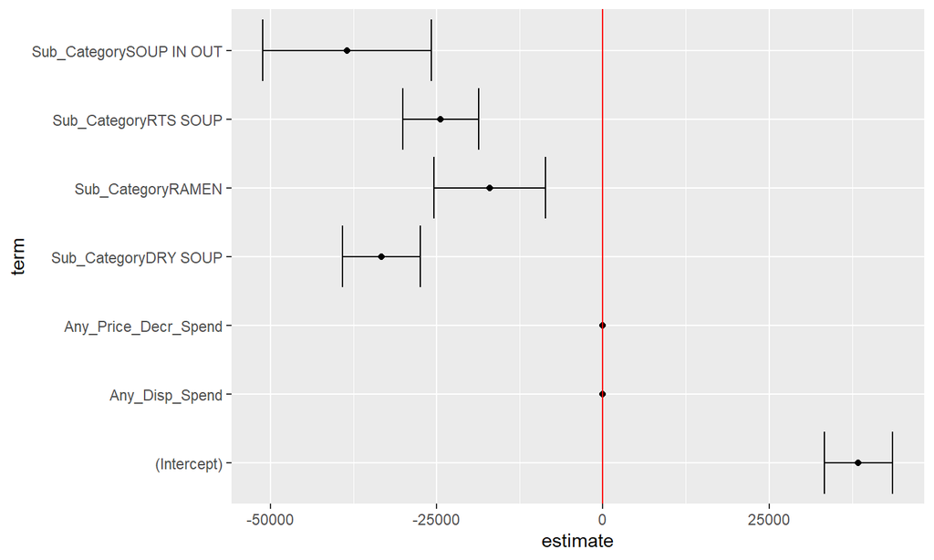

## Error Bar plot for Pre-processed Data

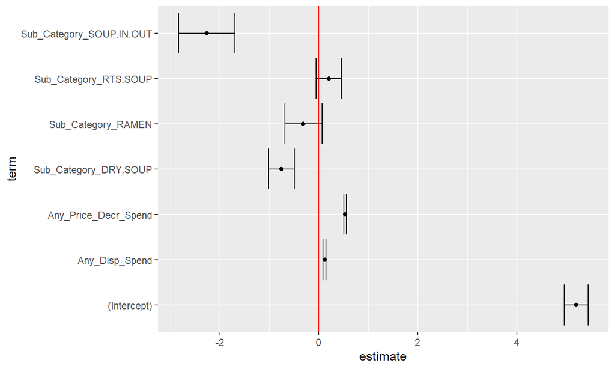

How does the log transform change parameter interpretations?

- *y* and \(x_1\): A **one unit increase** in \(x_1\) leads to a **\(\beta_1\) unit change** in *y* (relative to the baseline level of \(x_1\)), holding all other variables fixed.
- log(*y*) and \(x_1\): A **one unit increase** in \(x_1\) leads to a **100 × \(\beta_1\)% change** in *y* (relative to the baseline level of \(x_1\)), holding all other variables fixed.
- *y* and log(\(x_1\)): A **1% increase** in \(x_1\) leads to a **\(\beta_1\)/100 unit change** in *y* (relative to the baseline level of \(x_1\)), holding all other variables fixed.
- log(*y*) and log(\(x_1\)): A **1% increase** in \(x_1\) leads to a **\(\beta_1\)% change** in *y* (relative to the baseline level of \(x_1\)), holding all other variables fixed.

## Your Turn!

We need to compute the RMSE of our two models using the testing data. Make sure to apply all necessary pre-processing steps to the testing data before applying the model that was trained on the pre-processed training data.

[output not shown]

## Solution

```r
# Apply the recipe to the testing data.
# THIS is why recipes are so helpful - they allow you to save
# your pre-processing steps and apply them across different data frames
baked_soup_testing <- soup_recipe |>
  bake(testing(soup_split))

bind_rows(
  # Compute RMSE without preprocessed testing data.
  predict(fit_raw, new_data = testing(soup_split)) |>
    bind_cols(testing(soup_split)) |>
    rmse(truth = Sales, estimate = .pred),
  # Compute RMSE with preprocessed testing data.
  predict(fit_baked, new_data = baked_soup_testing) |>
    bind_cols(baked_soup_testing) |>
    rmse(truth = Sales, estimate = .pred)
)
```

## Wait…Were the Previous RMSE values Comparable?

## Wait…Were the Previous RMSE values Comparable?

No! One of our error measures was computed on the log-scale. We need to either transform the predictions of our first model using the `log()` function, or transform the predictions of the second model using the `exp()` function.

## The Model Improved…But not THAT Much

Evaluation on raw scale.

```r
bind_rows(
  # Compute RMSE without preprocessed testing data.
  predict(fit_raw, new_data = testing(soup_split)) |>
    bind_cols(testing(soup_split)) |>
    rmse(truth = Sales, estimate = .pred),
  # Compute RMSE after transforming predictions from preprocessed testing data
  predict(fit_baked, new_data = baked_soup_testing) |>
    bind_cols(testing(soup_split)) |>
    mutate(.pred = exp(.pred)) |>
    rmse(truth = Sales, estimate = .pred)
)
```

```
## # A tibble: 2 × 3
##   .metric .estimator .estimate
##   <chr>   <chr>          <dbl>
## 1 rmse    standard      41040.
## 2 rmse    standard      39296.
```

## The Model Improved…But not THAT Much

Evaluation on log scale.

```r
bind_rows(
  # Compute RMSE after transforming predictions from raw testing data.
  predict(fit_raw, new_data = testing(soup_split)) |>
    bind_cols(baked_soup_testing) |>
    mutate(.pred = log(.pred)) |>
    rmse(truth = Sales, estimate = .pred),
  # Compute RMSE for predictions from preprocessed testing data
  predict(fit_baked, new_data = baked_soup_testing) |>
    bind_cols(baked_soup_testing) |>
    rmse(truth = Sales, estimate = .pred)
)
```

```
## # A tibble: 2 × 3
##   .metric .estimator .estimate
##   <chr>   <chr>          <dbl>
## 1 rmse    standard        3.53
## 2 rmse    standard        2.36
```

## Apply a Recipe for Prediction

Having all of the preprocessing steps saved as a recipe means we can easily apply it to `new_data` when using `predict()` to evaluate counterfactuals. Construct the counterfactual data in the same form as the raw data so that it will work with our recipe.

## Recall the Format of the Raw Data

```r
soup_data |>
  select(Any_Disp_Spend, Any_Price_Decr_Spend, Sub_Category, Sales)
```

```
## # A tibble: 3,192 × 4
##    Any_Disp_Spend Any_Price_Decr_Spend Sub_Category    Sales
##             <dbl>                <dbl> <chr>           <dbl>
##  1              0                    0 CONDENSED SOUP    839
##  2          16489                48977 CONDENSED SOUP 468607
##  3              0                    0 CONDENSED SOUP     91
##  4              0                 1954 CONDENSED SOUP 139993
##  5              0                    0 DRY SOUP           50
##  6              0                    0 DRY SOUP        27456
##  7              0                    0 DRY SOUP          135
##  8              0                    0 DRY SOUP            0
##  9              9                    0 DRY SOUP         6257
## 10              0                    0 DRY SOUP            4
## # ℹ 3,182 more rows
```

## Construct Counterfactuals

Allocate $10,000 spend between display and price decreases for each sub-category.

```r
# Counterfactual scenarios.
scenarios <- tibble(
  # compute display spend numbers, repeat them 5 times, once for each category
  Any_Disp_Spend = seq(from = 0, to = 10000, by = 2000) |> rep(5),
  # compute price decrease spend numbers, repeat them 5 times, once for each category
  Any_Price_Decr_Spend = seq(from = 10000, to = 0, by = -2000) |> rep(5),
  # character vector of subcategories, repeated six times six we have six counterfactual scenarios
  # in each sub-category
  Sub_Category = unique(soup_data$Sub_Category) |> rep(6) |> sort(),
  Sales = 1
)
```

What’s different about this `new_data`? How can we interpret each of the rows?

```r
scenarios
```

```
## # A tibble: 30 × 4
##    Any_Disp_Spend Any_Price_Decr_Spend Sub_Category   Sales
##             <dbl>                <dbl> <chr>          <dbl>
##  1              0                10000 CONDENSED SOUP     1
##  2           2000                 8000 CONDENSED SOUP     1
##  3           4000                 6000 CONDENSED SOUP     1
##  4           6000                 4000 CONDENSED SOUP     1
##  5           8000                 2000 CONDENSED SOUP     1
##  6          10000                    0 CONDENSED SOUP     1
##  7              0                10000 DRY SOUP           1
##  8           2000                 8000 DRY SOUP           1
##  9           4000                 6000 DRY SOUP           1
## 10           6000                 4000 DRY SOUP           1
## # ℹ 20 more rows
```

Apply the recipe and remove the outcome variable before using the new data for `predict()`.

```r
# Apply the recipe to the training data.
baked_scenarios <- soup_recipe |>
  bake(scenarios) |>
  select(-Sales)

baked_scenarios
```

```
## # A tibble: 30 × 6
##    Any_Disp_Spend Any_Price_Decr_Spend Sub_Category_DRY.SOUP Sub_Category_RAMEN
##             <dbl>                <dbl>                 <dbl>              <dbl>
##  1           0                    9.21                     0                  0
##  2           7.60                 8.99                     0                  0
##  3           8.29                 8.70                     0                  0
##  4           8.70                 8.29                     0                  0
##  5           8.99                 7.60                     0                  0
##  6           9.21                 0                        0                  0
##  7           0                    9.21                     1                  0
##  8           7.60                 8.99                     1                  0
##  9           8.29                 8.70                     1                  0
## 10           8.70                 8.29                     1                  0
## # ℹ 20 more rows
## # ℹ 2 more variables: Sub_Category_RTS.SOUP <dbl>,
## #   Sub_Category_SOUP.IN.OUT <dbl>
```

Generate point predictions and predictive intervals.

```r
# Predict and bind on prediction intervals.
bind_cols(
  predict(fit_baked, new_data = baked_scenarios),
  predict(fit_baked, new_data = baked_scenarios, type = "pred_int"),
  baked_scenarios
) |>
  arrange(desc(.pred))
```

```
## # A tibble: 30 × 9
##    .pred .pred_lower .pred_upper Any_Disp_Spend Any_Price_Decr_Spend
##    <dbl>       <dbl>       <dbl>          <dbl>                <dbl>
##  1  11.0        7.21        14.9           7.60                 8.99
##  2  11.0        7.13        14.8           8.29                 8.70
##  3  10.8        7.00        14.7           7.60                 8.99
##  4  10.8        6.96        14.6           8.70                 8.29
##  5  10.8        6.93        14.6           8.29                 8.70
##  6  10.6        6.76        14.4           8.70                 8.29
##  7  10.5        6.69        14.4           7.60                 8.99
##  8  10.5        6.63        14.3           8.99                 7.60
##  9  10.5        6.61        14.3           8.29                 8.70
## 10  10.3        6.46        14.1           0                    9.21
## # ℹ 20 more rows
## # ℹ 4 more variables: Sub_Category_DRY.SOUP <dbl>, Sub_Category_RAMEN <dbl>,
## #   Sub_Category_RTS.SOUP <dbl>, Sub_Category_SOUP.IN.OUT <dbl>
```

## Other Preprocessing Steps

We can manually wrangle everything that a step function can do, but step functions can be a lot easier to use. Beyond `step_log()` and `step_dummy()`, for example:

- `step_corr()` to check for multicollinearity and drop explanatory variables.
- `step_normalize()` to subtract the mean and divide by the variance.
- `step_discretize()` to make a continuous variable discrete.
- `step_num2factor()` to quickly turn a numeric variable into a factor.

We also have additional helper functions like `all_predictors()`.

## Final Note: Important!

REMEMBER THESE POINTS:

Preprocessing occurs in three places in our analysis.

AFTER you do the train-test split,

1. on the training data, prior to training your model(s).
2. on the testing data, prior to generating predictions to evaluate model fit.
3. on the counterfactuals, prior to generating counterfactual predictions
- Make sure you reverse any pre-processing steps necessary for your predictions to be on the original scale.

## Live Coding

Our old client, **iFood**, has requested an updated model for total sales. Now that we have knowledge of various pre-processing skills, let’s build and assess a new model for them.

## Wrapping Up

*Summary*

- Walked through preprocessing data using recipes.
- Demonstrated the log transform and dummy coding.

*Next Time*

- What if the outcome isn’t continuous?

*Supplementary Material*

- *Tidy Modeling with R* Chapter 8

*Artwork by @allison_horst*

## Exercise 11

Return again to `soup_data` and your models used in Exercises 9 and 10.

1. Check for right-skewed continuous variables.
2. Prepare a recipe using the necessary steps.
3. Fit the models from the previous exercises again on the preprocessed training data.
4. Compute the RMSE again using the preprocessed testing data. Is the same model as last time still the best-fitting model?
5. Use the best-fitting model (based on RMSE) and predict `Sales` using three possible ways to split $6000 for the promotions budget. As with the training and testing data, be sure to preprocess the new data. What should the client do with their promotional budget? Provide an interpretation using dollars.
6. Render the Quarto document into Word and upload to Canvas.